# Concrete Strength

## GitHub URL: https://github.com/gsahai1x/AIML

```python
import warnings
warnings.filterwarnings('ignore')
```

### Problem Statement: Concrete Strength Prediction

### Objective

> *To predict the concrete strength using the data available in file "concrete.csv". Apply feature engineering and model tuning to obtain a score above 85%.

### Resources Available

> *The data for this project is available in file https://archive.ics.uci.edu/ml/machine-learning-databases/concrete/compressive/. The same has been shared along with the course content.

### Steps and Tasks:

#### Exploratory Data Quality Report Reflecting the Following:

> - Univariate analysis –data types and description of the independent attributes which should include (name, range of values observed, central values (mean and median), standard deviation and quartiles, analysis of the body of distributions/tails, missing values, outliers, duplicates(10 Marks)
> - Bi-variate analysis between the predictor variables and between the predictor variables and target column. Comment on your findings in terms of their relationship and degree of relation if any. Visualize the analysis using boxplots and pair plots, histograms, or density curves. (10 marks)
> - Feature Engineering techniques(10 marks)
> - Identify opportunities (if any) to extract new features from existing features, drop a feature(if required) Hint: Feature Extraction, for example, consider a dataset with two features length and breadth. From this, we can extract a new feature Area which would be length * breadth.
> - Get the data model ready and do a train test split.
> - Decide on the complexity of the model, should it be a simple linear model in terms of parameters or would a quadratic or higher degree.

#### Creating the Model and Tuning It:

> - Algorithms that you think will be suitable for this project. Use Kfold Cross-Validation to evaluate model performance. Use appropriate metrics and make a DataFrame to compare models w.r.t their metrics. (at least 3 algorithms, one bagging and one boosting based algorithms have to be there). (15 marks)
> - Techniques employed to squeeze that extra performance out of the model without making it overfit. Use Grid Search or Random Search on any of the two models used above. Make a DataFrame to compare models after hyperparameter tuning and their metrics as above. (15 marks)

### Attribute Information:

> - Given are the variable name, variable type, the measurement unit, and a brief description. The concrete compressive strength is the regression problem. The order of this listing corresponds to the order of numerals along the rows of the database.

#### Name Data Type Measurement Description

1. Cement (cement) quantitative kg in a m3 mixture Input Variable
2. Blast Furnace Slag (slag) quantitative kg in a m3 mixture Input Variable
3. Fly Ash (ash) quantitative kg in a m3 mixture Input Variable
4. Water(water) quantitative kg in a m3 mixture Input Variable
5. Superplasticizer (superplastic) quantitative kg in a m3 mixture Input Variable
6. Coarse Aggregate (coarseagg) quantitative kg in a m3 mixture Input Variable
7. Fine Aggregate (fineagg) quantitative kg in a m3 mixture Input Variable
8. Age(age) quantitative Day (1~365) Input Variable
9. Concrete compressive strength(strength) quantitative MPa Output Variable

### Import Libraries

```python
import numpy as np
import pandas as pd
import matplotlib.pyplot as plt
import seaborn as sns
%matplotlib inline
import pandas_profiling
from sklearn.model_selection import train_test_split
from sklearn.tree import DecisionTreeClassifier
from sklearn import metrics
from yellowbrick.classifier import ClassificationReport, ROCAUC
plt.style.use('ggplot')
pd.options.display.float_format = '{:,.2f}'.format
from IPython.core.display import display, HTML
display(HTML("<style>.container { width:95% !important; }</style>"))
from sklearn import set_config
set_config(print_changed_only=False)
from sklearn.metrics import mean_squared_error
from sklearn.preprocessing import StandardScaler
from sklearn.decomposition import PCA
from sklearn.linear_model import LinearRegression
from sklearn.pipeline import Pipeline
from sklearn.model_selection import KFold
from sklearn.model_selection import train_test_split, cross_val_score, cross_val_predict,StratifiedKFold
from sklearn.ensemble import RandomForestRegressor
from sklearn.ensemble import BaggingRegressor
from sklearn.ensemble import ExtraTreesRegressor
from sklearn.ensemble import GradientBoostingRegressor
from sklearn.model_selection import GridSearchCV
```

```python
#import Data
df = pd.read_csv('concrete.csv')
```

```python
#Read first few records
df.head()
```

|  | cement | slag | ash | water | superplastic | coarseagg | fineagg | age | strength |
| --- | --- | --- | --- | --- | --- | --- | --- | --- | --- |
| 0 | 141.30 | 212.00 | 0.00 | 203.50 | 0.00 | 971.80 | 748.50 | 28 | 29.89 |
| 1 | 168.90 | 42.20 | 124.30 | 158.30 | 10.80 | 1,080.80 | 796.20 | 14 | 23.51 |
| 2 | 250.00 | 0.00 | 95.70 | 187.40 | 5.50 | 956.90 | 861.20 | 28 | 29.22 |
| 3 | 266.00 | 114.00 | 0.00 | 228.00 | 0.00 | 932.00 | 670.00 | 28 | 45.85 |
| 4 | 154.80 | 183.40 | 0.00 | 193.30 | 9.10 | 1,047.40 | 696.70 | 28 | 18.29 |

### Univariate Analysis

```python
#Get information related to data types, column names, null counts and range
df.info()
```

```
<class 'pandas.core.frame.DataFrame'>
RangeIndex: 1030 entries, 0 to 1029
Data columns (total 9 columns):
 #   Column        Non-Null Count  Dtype
---  ------        --------------  -----
 0   cement        1030 non-null   float64
 1   slag          1030 non-null   float64
 2   ash           1030 non-null   float64
 3   water         1030 non-null   float64
 4   superplastic  1030 non-null   float64
 5   coarseagg     1030 non-null   float64
 6   fineagg       1030 non-null   float64
 7   age           1030 non-null   int64
 8   strength      1030 non-null   float64
dtypes: float64(8), int64(1)
memory usage: 72.5 KB
```

```python
df.shape
```

```
(1030, 9)
```

> - there are 9 columns and 1030 rows. 8 features and 1 label

```python
#Get details related to counts, mean, std, min, max, and quartiles
df.describe().T
```

|  | count | mean | std | min | 25% | 50% | 75% | max |
| --- | --- | --- | --- | --- | --- | --- | --- | --- |
| cement | 1,030.00 | 281.17 | 104.51 | 102.00 | 192.38 | 272.90 | 350.00 | 540.00 |
| slag | 1,030.00 | 73.90 | 86.28 | 0.00 | 0.00 | 22.00 | 142.95 | 359.40 |
| ash | 1,030.00 | 54.19 | 64.00 | 0.00 | 0.00 | 0.00 | 118.30 | 200.10 |
| water | 1,030.00 | 181.57 | 21.35 | 121.80 | 164.90 | 185.00 | 192.00 | 247.00 |
| superplastic | 1,030.00 | 6.20 | 5.97 | 0.00 | 0.00 | 6.40 | 10.20 | 32.20 |
| coarseagg | 1,030.00 | 972.92 | 77.75 | 801.00 | 932.00 | 968.00 | 1,029.40 | 1,145.00 |
| fineagg | 1,030.00 | 773.58 | 80.18 | 594.00 | 730.95 | 779.50 | 824.00 | 992.60 |
| age | 1,030.00 | 45.66 | 63.17 | 1.00 | 7.00 | 28.00 | 56.00 | 365.00 |
| strength | 1,030.00 | 35.82 | 16.71 | 2.33 | 23.71 | 34.45 | 46.14 | 82.60 |

> - Slag, Ash, Superplastic - all have 0 values
> - There are 1030 records
> - Median for ash is 0. It is likely that ash has a lot of values as 0.
> - Cement has very high standard deviation

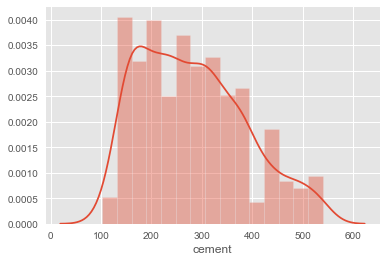

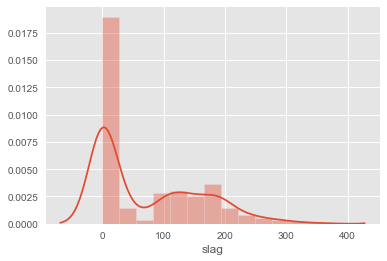

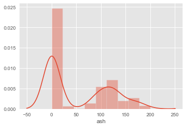

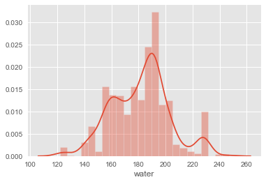

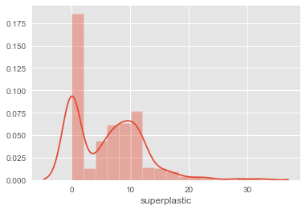

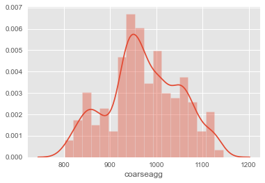

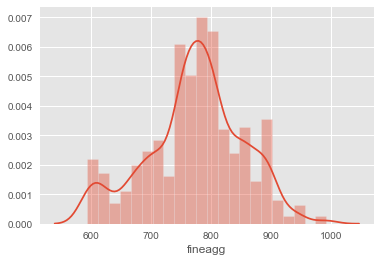

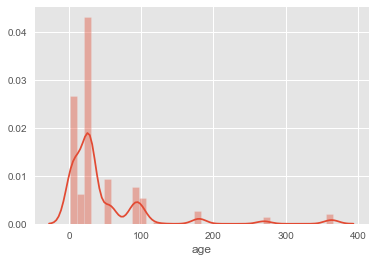

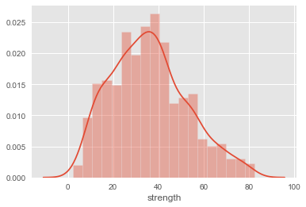

```python
#get distribution plot
for col in ['cement', 'slag', 'ash', 'water', 'superplastic', 'coarseagg',
       'fineagg', 'age', 'strength']:
    ax = sns.distplot(df[col])
    plt.show()
```

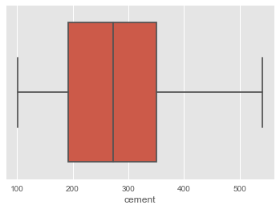

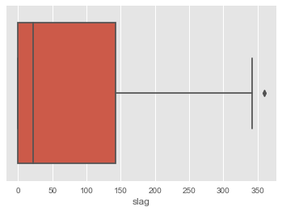

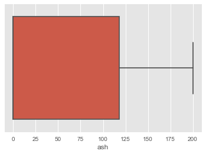

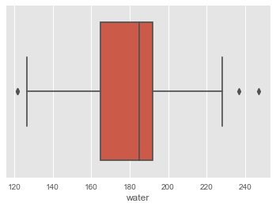

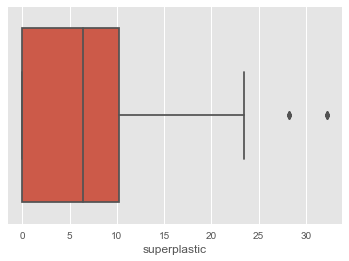

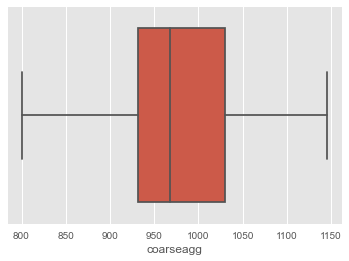

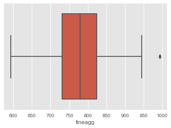

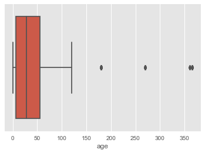

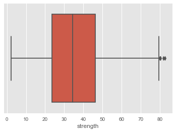

```python
#get outliers
for col in df.columns:
    ax = sns.boxplot(df[col])
    plt.show()
```

> - slag, water, superplastic, fineagg, and age all have outliers. age has the most.

```python
#get null true/false
df.isnull().any()
```

```
cement          False
slag            False
ash             False
water           False
superplastic    False
coarseagg       False
fineagg         False
age             False
strength        False
dtype: bool
```

> - No null values

```python
#get null count
df.isna().sum()
```

```
cement          0
slag            0
ash             0
water           0
superplastic    0
coarseagg       0
fineagg         0
age             0
strength        0
dtype: int64
```

> - No null values

```python
#get duplicates
df[df.duplicated() == True]
```

|  | cement | slag | ash | water | superplastic | coarseagg | fineagg | age | strength |
| --- | --- | --- | --- | --- | --- | --- | --- | --- | --- |
| 278 | 425.00 | 106.30 | 0.00 | 153.50 | 16.50 | 852.10 | 887.10 | 3 | 33.40 |
| 298 | 425.00 | 106.30 | 0.00 | 153.50 | 16.50 | 852.10 | 887.10 | 3 | 33.40 |
| 400 | 362.60 | 189.00 | 0.00 | 164.90 | 11.60 | 944.70 | 755.80 | 3 | 35.30 |
| 420 | 362.60 | 189.00 | 0.00 | 164.90 | 11.60 | 944.70 | 755.80 | 3 | 35.30 |
| 463 | 362.60 | 189.00 | 0.00 | 164.90 | 11.60 | 944.70 | 755.80 | 56 | 77.30 |
| 468 | 252.00 | 0.00 | 0.00 | 185.00 | 0.00 | 1,111.00 | 784.00 | 28 | 19.69 |
| 482 | 425.00 | 106.30 | 0.00 | 153.50 | 16.50 | 852.10 | 887.10 | 91 | 65.20 |
| 493 | 362.60 | 189.00 | 0.00 | 164.90 | 11.60 | 944.70 | 755.80 | 91 | 79.30 |
| 517 | 425.00 | 106.30 | 0.00 | 153.50 | 16.50 | 852.10 | 887.10 | 56 | 64.30 |
| 525 | 362.60 | 189.00 | 0.00 | 164.90 | 11.60 | 944.70 | 755.80 | 28 | 71.30 |
| 527 | 425.00 | 106.30 | 0.00 | 153.50 | 16.50 | 852.10 | 887.10 | 91 | 65.20 |
| 576 | 362.60 | 189.00 | 0.00 | 164.90 | 11.60 | 944.70 | 755.80 | 7 | 55.90 |
| 577 | 425.00 | 106.30 | 0.00 | 153.50 | 16.50 | 852.10 | 887.10 | 28 | 60.29 |
| 604 | 362.60 | 189.00 | 0.00 | 164.90 | 11.60 | 944.70 | 755.80 | 56 | 77.30 |
| 733 | 362.60 | 189.00 | 0.00 | 164.90 | 11.60 | 944.70 | 755.80 | 91 | 79.30 |
| 738 | 362.60 | 189.00 | 0.00 | 164.90 | 11.60 | 944.70 | 755.80 | 28 | 71.30 |
| 766 | 362.60 | 189.00 | 0.00 | 164.90 | 11.60 | 944.70 | 755.80 | 91 | 79.30 |
| 830 | 425.00 | 106.30 | 0.00 | 153.50 | 16.50 | 852.10 | 887.10 | 7 | 49.20 |
| 880 | 425.00 | 106.30 | 0.00 | 153.50 | 16.50 | 852.10 | 887.10 | 56 | 64.30 |
| 884 | 425.00 | 106.30 | 0.00 | 153.50 | 16.50 | 852.10 | 887.10 | 7 | 49.20 |
| 892 | 362.60 | 189.00 | 0.00 | 164.90 | 11.60 | 944.70 | 755.80 | 56 | 77.30 |
| 933 | 362.60 | 189.00 | 0.00 | 164.90 | 11.60 | 944.70 | 755.80 | 7 | 55.90 |
| 943 | 362.60 | 189.00 | 0.00 | 164.90 | 11.60 | 944.70 | 755.80 | 3 | 35.30 |
| 967 | 362.60 | 189.00 | 0.00 | 164.90 | 11.60 | 944.70 | 755.80 | 28 | 71.30 |
| 992 | 425.00 | 106.30 | 0.00 | 153.50 | 16.50 | 852.10 | 887.10 | 28 | 60.29 |

```python
#count duplicates
df[df.duplicated() == True].count()
```

```
cement          25
slag            25
ash             25
water           25
superplastic    25
coarseagg       25
fineagg         25
age             25
strength        25
dtype: int64
```

> - There are around 25 duplicates

```python
#drop duplicates
df = df.drop_duplicates()
```

> - Drop Duplicates

```python
df.shape
```

```
(1005, 9)
```

> - After dropping duplicates, 1005 records remain out of 1030.

### Bivariate Analysis

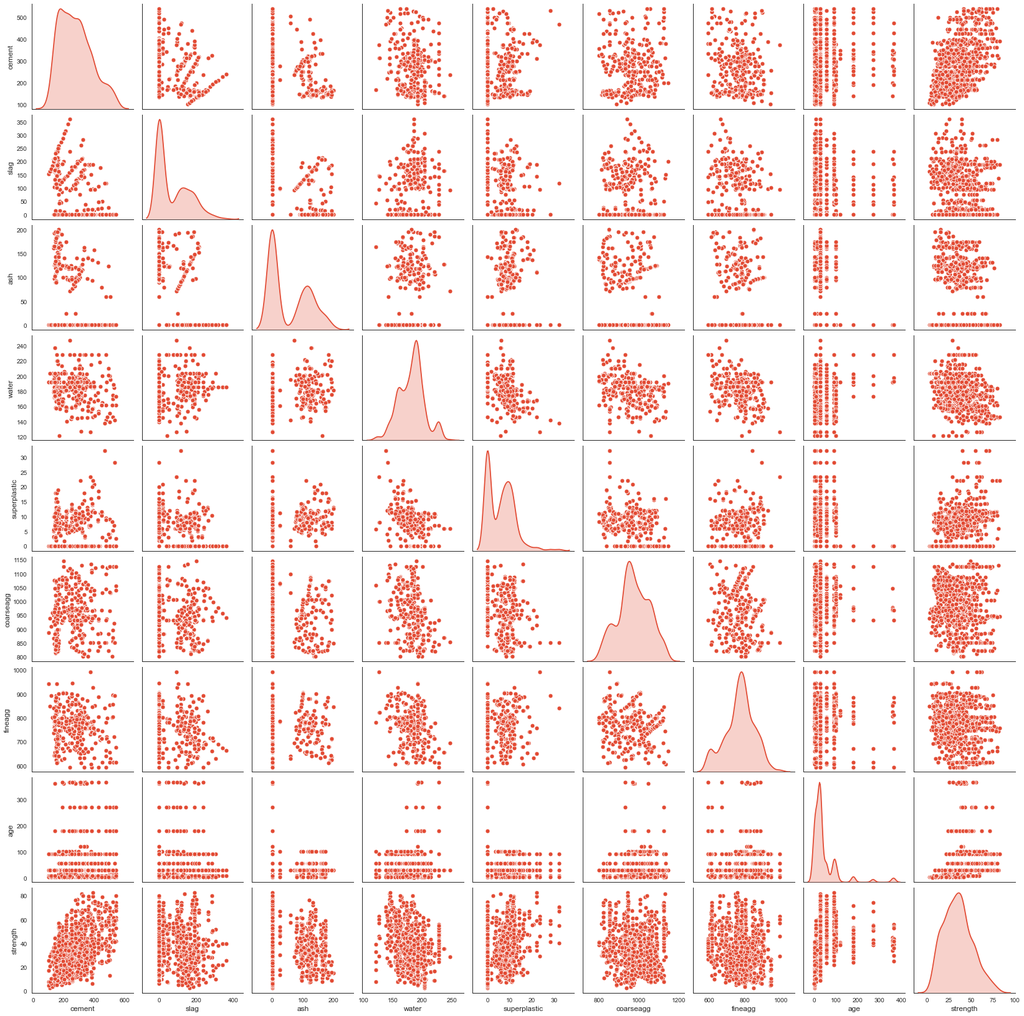

```python
#pairplot to show if there are any visible relations between each feature and label
sns.set_style('ticks')
sns.pairplot(df, diag_kind='kde')
```

> - Cement and Strength seems to have positive relation.
> - Strength seems to be higher with higher age.

```python
#get value counts
for col in df.columns:
    print(df[col].value_counts())
```

```
251.40    15
446.00    14
310.00    14
250.00    13
475.00    13
          ..
276.40     1
151.80     1
164.20     1
160.20     1
158.60     1
Name: cement, Length: 278, dtype: int64
0.00      470
189.00     16
24.00      14
20.00      12
145.00     11
         ...
163.90      1
160.50      1
166.40      1
186.70      1
164.20      1
Name: slag, Length: 185, dtype: int64
0.00      541
118.30     20
141.00     16
24.50      15
79.00      14
         ...
90.30       1
108.60      1
194.90      1
160.90      1
89.60       1
Name: ash, Length: 156, dtype: int64
192.00    118
228.00     54
185.70     46
203.50     36
```

[output cut: 56 more lines]

```
120      3
1        2
Name: age, dtype: int64
33.40    4
41.05    4
31.35    4
23.52    4
42.13    3
        ..
29.93    1
35.17    1
56.63    1
35.76    1
15.75    1
Name: strength, Length: 845, dtype: int64
```

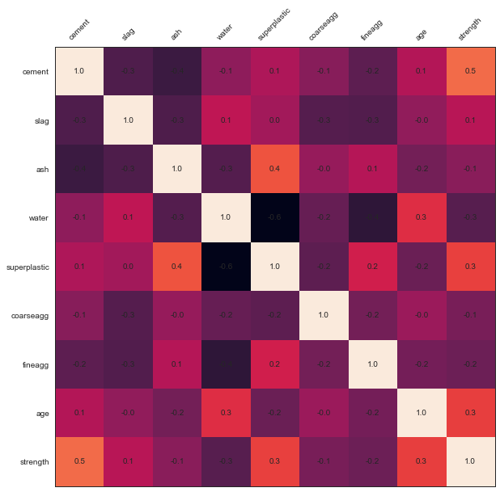

```python
#get correlation
def plot_corr(df, size=10):
    corr = df.corr()
    fig, ax = plt.subplots(figsize=(size, size))
    ax.matshow(corr)
    plt.xticks(range(len(corr.columns)), corr.columns, rotation=45)
    plt.yticks(range(len(corr.columns)), corr.columns)
    for (i, j), z in np.ndenumerate(corr):
        ax.text(j, i, '{:0.1f}'.format(z), ha='center', va='center')
plot_corr(df)
```

> - Correlation between strength and cement
> - Correlation between ash and superplastic. It looks like the ash will be less if there is less plastic.

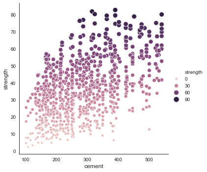

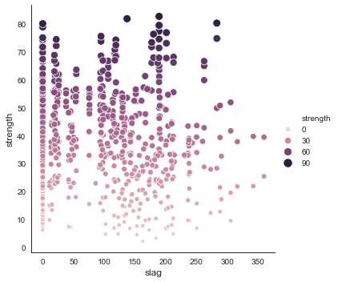

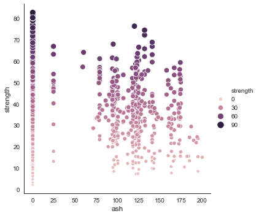

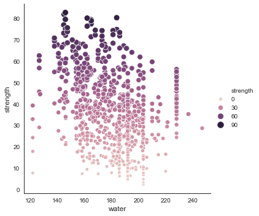

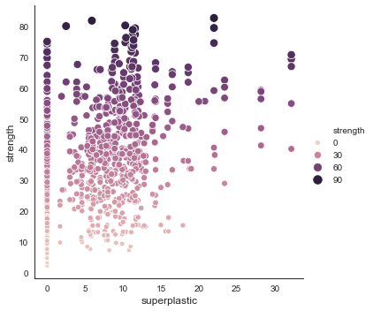

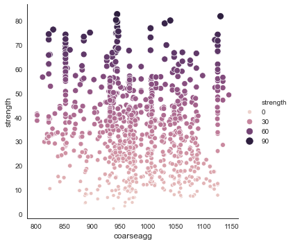

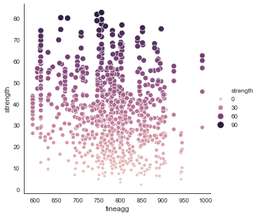

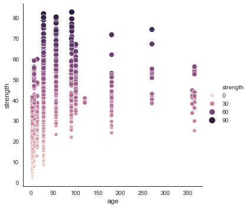

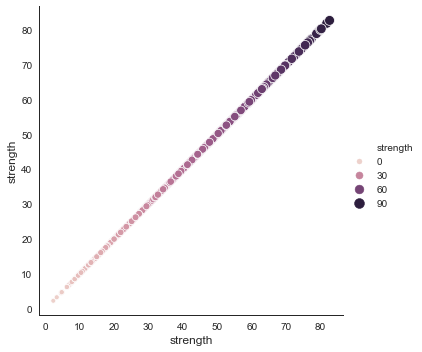

```python
#get a relation plot with strength
for col in df.columns:
    sns.relplot(x=col,y='strength', hue='strength',size='strength', data=df)
    plt.show()
```

> - Strength goes up with cement
> - Water levels at certain level to have more strength. Higher and lower water levels can lead to lower strength
> - Age between 40 - 100 seems to have a higher strength

#### Highlights

> - Relation between strength and cement, ash and superplastic, strength and age